# 市区町村データによる大学・大学院卒者割合の可視化

1都3県の例

[岩田真一郎](https://shinichiro-iwata.github.io/)（ [神奈川大学経済学部](https://www.econ.kanagawa-u.ac.jp/)）

2022-11-21作成，2025-02-10改定

# 1 目的

市区町村データをダウンロードし，シェープファイルと結合し，可視化．

パッケージ：`tidyverse`，`sf`

```r
library(tidyverse)
library(sf)
```

# 2 学歴ダウンロード

- [都道府県・市区町村のすがた（社会・人口統計体系）](https://www.e-stat.go.jp/regional-statistics/ssdsview) > 市区町村 > データ表示
  - 表示データ > 現在の市区町村
  - 地域区分 > 都道府県 > 埼玉県，千葉県，東京都，神奈川県
  - 絞り込み > デフォルトのまま（チェックのとおり）
- 「地域区分」で埼玉県を選択すると「地域候補」欄に埼玉県の市区町村が表示される．「全て選択する」をクリックすると，右の「選択中地域」欄に埼玉県の市区町村が表示される．
- 続いて「地域区分」で千葉県を選択し，同様の作業を繰り返す．「選択中地域」欄には埼玉県の市区町村の後に，千葉県の市区町村が示される．
- 東京都，神奈川県で同様の作業を繰り返す．
- これで「選択中地域」欄に 埼玉県，千葉県，東京都，神奈川県の市区町村が選ばれる．「確定」をクリック．
  - 絞り込み > データの種類：`基礎データ` > 分野：`#E 教育`
  - 項目候補 > `#E9101　最終学歴人口（卒業者総数）（人）`，`#E9106　最終学歴人口（大学・大学院）（人）` > 確定
- ここでは次の形式でダウンロード．
  - 画面右上に表示される「ダウンロード」をクリック．
  - **オプション**を**「**ページ上部の選択項目，CSV形式，ヘッダ出力しない，コード出力する，階層コード出力しない，凡例出力しない，注釈を表示するのチェックを外す，桁区切り(,)を使用しない**」**とし，CSV形式のデータをダウンロード．
  - ダウンロードしたファイルは同じフォルダー（ディレクトリ）に格納．
- `read.csv()`：csvファイルの読込．`edu_back`と名付ける．
  - `sep=","`はデータがカンマで区切られていることを意味する．CSV形式のデータをメモ帳やEXCELで開くと，データがカンマで区切られていることがわかる．
  - `header=TRUE`は列名が含まれていることを意味する．仮に列名がなければ`FALSE`．`skip=1`は1番最初の行を削除することを意味する．CSV形式のデータをメモ帳やEXCELで開くと，最初の2行に列名（項目名）が記されている．ここでは，1行目は利用しない．
  - `fileEncoding="CP932"`により文字化けを回避．ただし，完全ではなく，列名の「.」は変換に失敗している．

```r
#最終学歴人口（卒業者総数），最終学歴人口（大学・大学院）の読込
edu_back <-
  read.csv("FEI_CITY_221121140604.csv",
             sep=",", header=TRUE, skip=1,
             fileEncoding="CP932")

#データの中身
edu_back
```

| 調査年.コード | 調査年 | 地域.コード | 地域 | X.項目 | E9101_最終学歴人口.卒業者総数..人. | E9106_最終学歴人口.大学.大学院..人. |
| --- | --- | --- | --- | --- | --- | --- |
| 2010100000 | 2010年度 | 11100 | 埼玉県 さいたま市 | NA | 959480 | 253800 |
| 2010100000 | 2010年度 | 11101 | 埼玉県 さいたま市 西区 | NA | 67154 | 13207 |
| 2010100000 | 2010年度 | 11102 | 埼玉県 さいたま市 北区 | NA | 107542 | 30022 |
| 2010100000 | 2010年度 | 11103 | 埼玉県 さいたま市 大宮区 | NA | 85619 | 25436 |
| 2010100000 | 2010年度 | 11104 | 埼玉県 さいたま市 見沼区 | NA | 123484 | 27375 |
| 2010100000 | 2010年度 | 11105 | 埼玉県 さいたま市 中央区 | NA | 76268 | 23464 |
| 2010100000 | 2010年度 | 11106 | 埼玉県 さいたま市 桜区 | NA | 73994 | 15425 |
| 2010100000 | 2010年度 | 11107 | 埼玉県 さいたま市 浦和区 | NA | 113712 | 42505 |
| 2010100000 | 2010年度 | 11108 | 埼玉県 さいたま市 南区 | NA | 136952 | 41584 |
| 2010100000 | 2010年度 | 11109 | 埼玉県 さいたま市 緑区 | NA | 84793 | 21992 |

[output cut: 246 more lines]

- 扱いやすいように変数名（列名）変更．
  - 変更する列：`3`列名（地域.コード），`6`列目（E9101_最終学歴人口.卒業者総数..人.），`7`列目（E9106_最終学歴人口.大学.大学院..人.）．

```r
#変数名（列名）の変更
edu_back %>%
  rename(city_code=3,
         graduate=6,
         univ_graduate=7) ->
  edu_back
```

**大学・大学院卒以上割合計算**

- 大学・大学院卒以上割合（`univ_ratio`）の列を加える．

```r
edu_back %>%
  mutate(univ_ratio=(univ_graduate/graduate)*100) ->
  edu_back
```

**利用しない市区町村の削除**

- 東京都の離島の市町村を削除．
  - 大島町，利島村，新島村，神津島村，三宅村，御蔵島村，八丈町，青ヶ島村），小笠原村を選抜．
  - 離島の市町村を1，離島ではない市（区）町村を0とする二値（ダミー）変数を作成．
  - `if_else()`を使用してダミー変数を作成する．
    - `if_else()`：第1引数に条件，第2引数に条件を満たす場合の値，第3引数に条件を満たさない場合の値を示す．

```
#if_else()利用を利用してダミー変数を作成する方法

if_else(条件式, 1, 0)
```

政令指定都市（さいたま市，千葉市，横浜市，川崎市，相模原市）は区レベルで表現したいため，取り除きたい．

- `filter()`を用いてデータ（`edu_back`）の一部を選抜．`filter()`内に利用するデータの条件を指示．`!=`は否定等号（左辺が右辺と等しくない）．すなわち，政令指定都市，離島の市町村ではない市区町村を利用するという条件．

```r
#離島市町村ダミーを作成
edu_back %>%
  mutate(island=
           ifelse(city_code>=13361 & city_code<=13421,
                  1, 0)) ->
  edu_back

#離島市町村と政令都市を除いたデータの選抜
edu_back %>%
  filter(city_code!=11100 & city_code!=12100 &
           city_code!=14100 & city_code!=14130 &
           city_code!=14150 & island!=1)->
  edu_back2
```

# 3 地図上への可視化

**境界データのダウンロード**

大学・大学院卒割合は現在の市区町村単位で計算しているため，行政区域は最新のファイルをダウンロード．

- [国土数値情報ダウンロードサービス](https://nlftp.mlit.go.jp/ksj/) > 行政区域（ポリゴン） > 埼玉県，千葉県，東京都，神奈川県 > 令和4年
  - ダウンロードしたZIPファイルは同じフォルダー（ディレクトリ）に納め，ZIPファイルを選択 > 右クリック > すべて展開 > 展開先の選択とファイルの選択 > 展開を実行する．展開後は最初にダウンロードしたZIPファイルを削除．
  - `read_sf()`：シェープファイル読込．
- `rbind()`：1都3県を一つのファイルに縦方向に合併．オブジェクトを`Greater_Tokyo`とする．

```r
#1都3県合併の行政区域のシェープファイルの読込
Saitama_map <-
  read_sf("N03-20220101_11_GML/N03-22_11_220101.shp")

Chiba_map <-
  read_sf("N03-20220101_12_GML/N03-22_12_220101.shp")

Tokyo_map <-
  read_sf("N03-20220101_13_GML/N03-22_13_220101.shp")

Kanagagawa_map <-
  read_sf("N03-20220101_14_GML/N03-22_14_220101.shp")

#1都3県合併
Greater_Tokyo <-
  rbind(Saitama_map, Chiba_map,
        Tokyo_map, Kanagagawa_map)
```

統計データ`edu_back`とシェープファイルの合併のための準備．

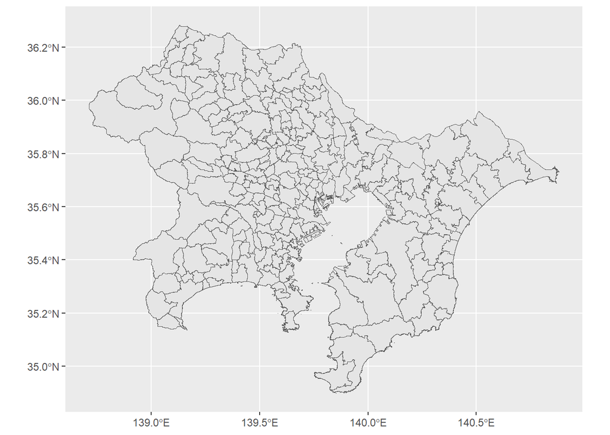

```r
#変数名の変更
Greater_Tokyo %>%
  rename(city_code=N03_007) ->
  Greater_Tokyo

#離島の市町村ダミーの作成
Greater_Tokyo %>%
  mutate(island=
           ifelse(city_code>=13361 & city_code<=13421,
                  1, 0)) ->
  Greater_Tokyo

#離島の市町村を除いたシェープファイルの作成
Greater_Tokyo %>%
  subset(island!=1)->
  Greater_Tokyo2

#可視化
ggplot()+
  geom_sf(data=Greater_Tokyo2)
```

# 4 大学・大学院卒業者割合の可視化

地図上に可視化．

- シェープファイル形式の地図データ（`Greater_Tokyo2`）と卒業者割合を格納した統計データ（`edu_back2`）を`city_code`で結合（left_join）し，改めてオブジェクトを`Greater_Tokyo2`とする．

```r
edu_back2 %>%
  mutate(city_code=as.character(city_code)) ->
  edu_back2

#地図データ（シェープファイル）と統計データとの合併
Greater_Tokyo2<-
  left_join(Greater_Tokyo2, edu_back2, by=c("city_code"))
```

**可視化**

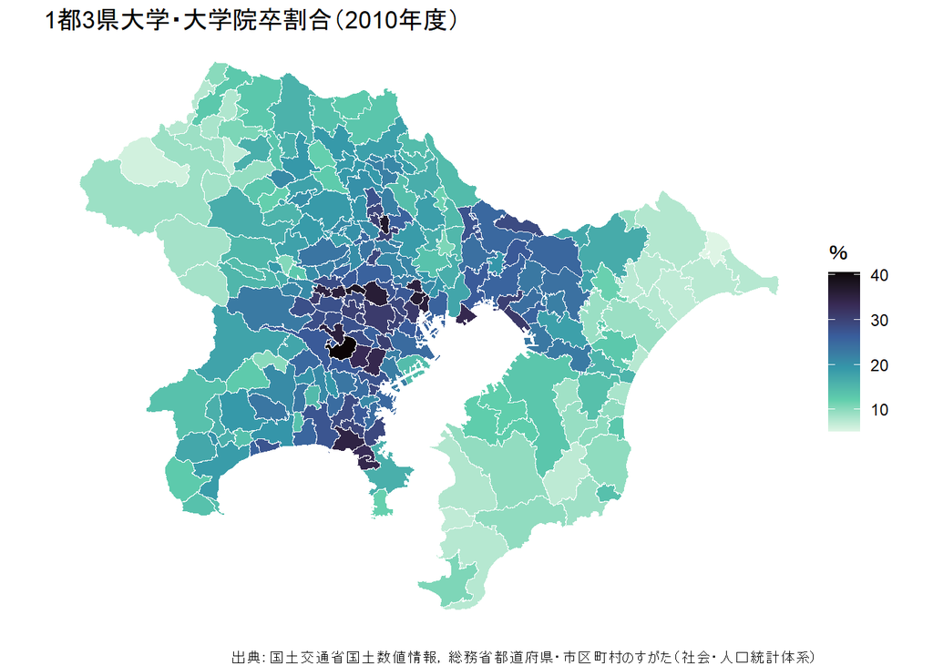

```r
ggplot()+
  geom_sf(data=Greater_Tokyo2, aes(fill=univ_ratio),
          color="white")+
  scale_fill_viridis_c(option="G", direction=-1)+
  labs(fill="％", x="", y="",
  caption="出典：国土交通省国土数値情報，総務省都道府県・市区町村のすがた（社会・人口統計体系）")+
  ggtitle("1都3県大学・大学院卒割合（2010年度）")+
  theme_void()
```

**Rによる地理空間データの可視化**

- チュートリアル[ホーム](https://shinichiro-iwata.github.io/geospatial-data-visualization/)